# Atelier pratique Git

Christopher Blier-Wong

9 février 2019

## Plan

- Apprendre à naviguer à l’aide de la ligne de commande
- Faire des changements dans le répertoire de travail
- Mettre à jour le dépôt à distance
- Mettre à jour l’environnement de travail
- Mises-en-situation

# Apprendre à naviguer à l’aide de la ligne de commande

## Quelques commandes utiles !

- ls
- cd (dir, .., cd)
- Tab !
- mkdir
- mv
- cp
- rm

## VIM en 1 minute

# Idées du versionnage

## Pourquoi faire du versionnage

- Système qui suit les changements dans un ensemble de fichiers
- Permet de retourner à une version du code qui fonctionne
- Retourner tout le projet à un état précédent
- Comparer les changements
- Modifier / corriger un bogue

## Nomenclature

- Dépôt (repositopry)
- Commit
- Branche (branch)
- master
- HEAD

## Le système de contrôle de version distribué

Merci pour l’inspiration !

https://git-scm.com/book/en/v2

https://github.com/rachelcarmena

## Le système de contrôle de version distribué

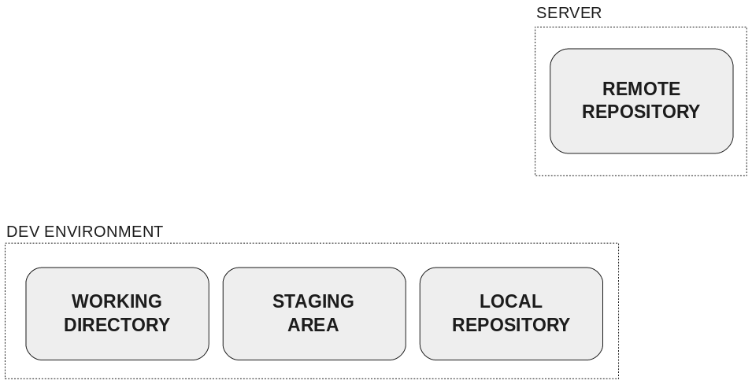

## Git status

- git status
- git status –short:
  - ??: Nouveau
  - A: Mis en scène
  - M: Modifié
  - _M: Modifié, non mis en scène
  - M_: Modifié et mis en scène

## Cloner un répertoire

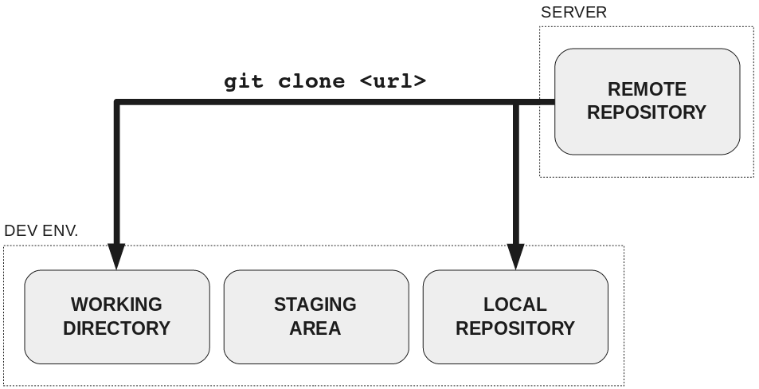

## Faire des changements dans un répertoire local

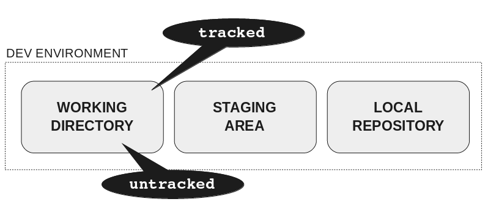

## Faire des changements dans un répertoire local

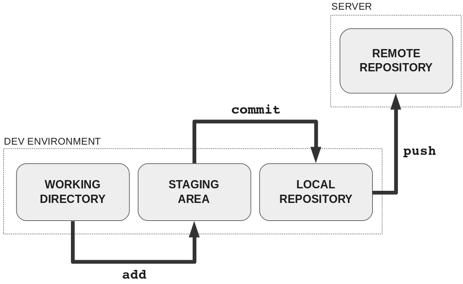

## Faire des changements dans un répertoire local

- Ajouter tous les fichiers : `git add -A`
- Ajouter les nouveaux fichiers et fichiers modifiés: `git add .`
- Ajouter les fichiers suivis et mis-à-jour (tracked) : `git add -u`
- Ajouter des changements dans chaque fichier : `git add -p`

| Commande | Nouveaux | Modifié | Supprimé |
| --- | --- | --- | --- |
| `git add -A` | Oui | Oui | Oui |
| `git add .` | Oui | Oui | Non |
| `git add -u` | Non | Oui | Oui |

## Faire des changements dans un répertoire local

- Défaire un changement : `git checkout -- fichier`
- Défaire un fichier dans la mise en scène `git reset HEAD -- fichier`
- Défaire tous les changements et mises en scènes `git reset HEAD --hard`

## Voir les changements

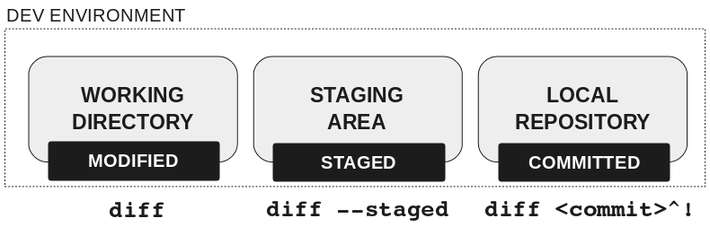

## Mettre à jour l’envoronnement de développement

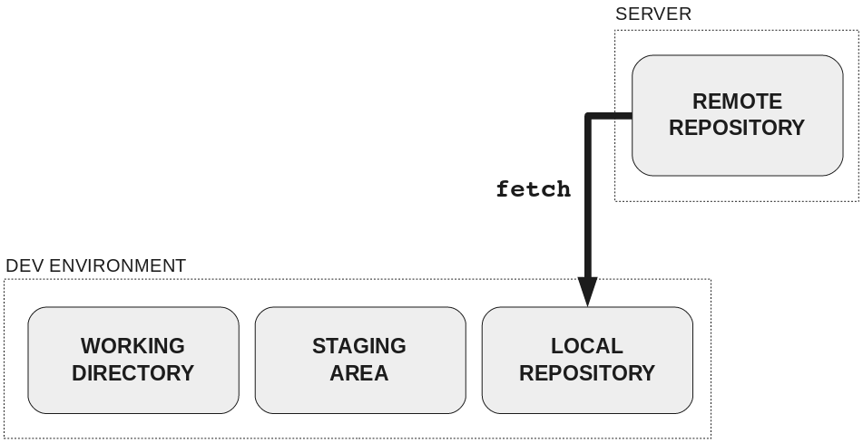

## Mettre à jour l’envoronnement de développement

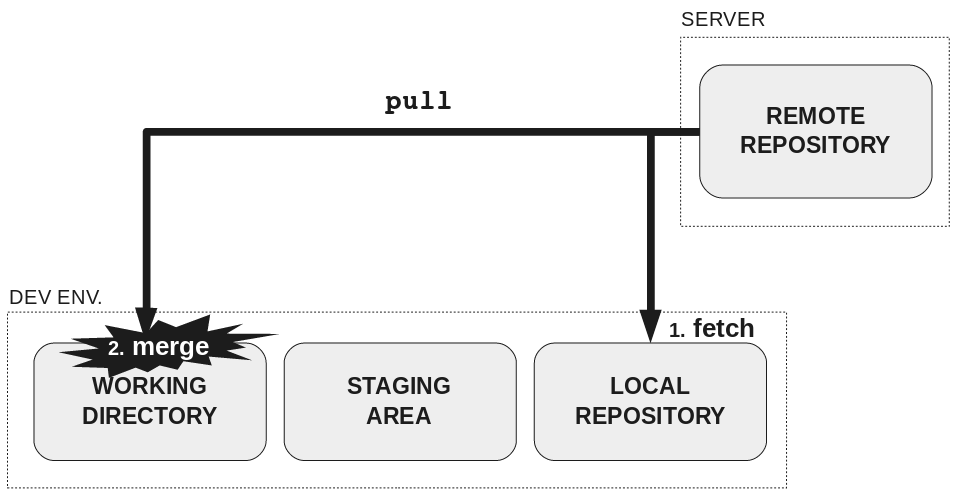

## Mettre à jour l’envoronnement de développement

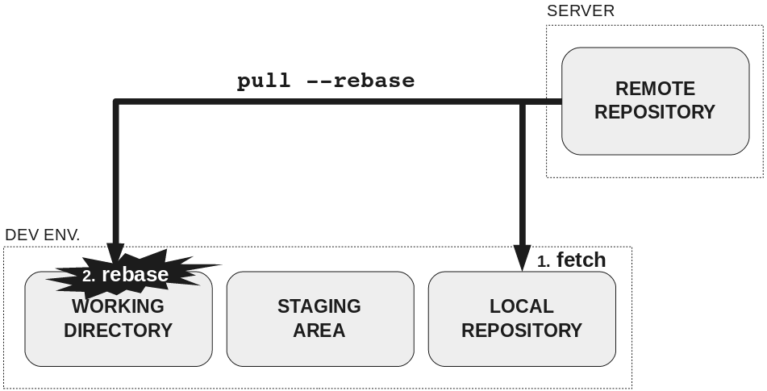

## Stash

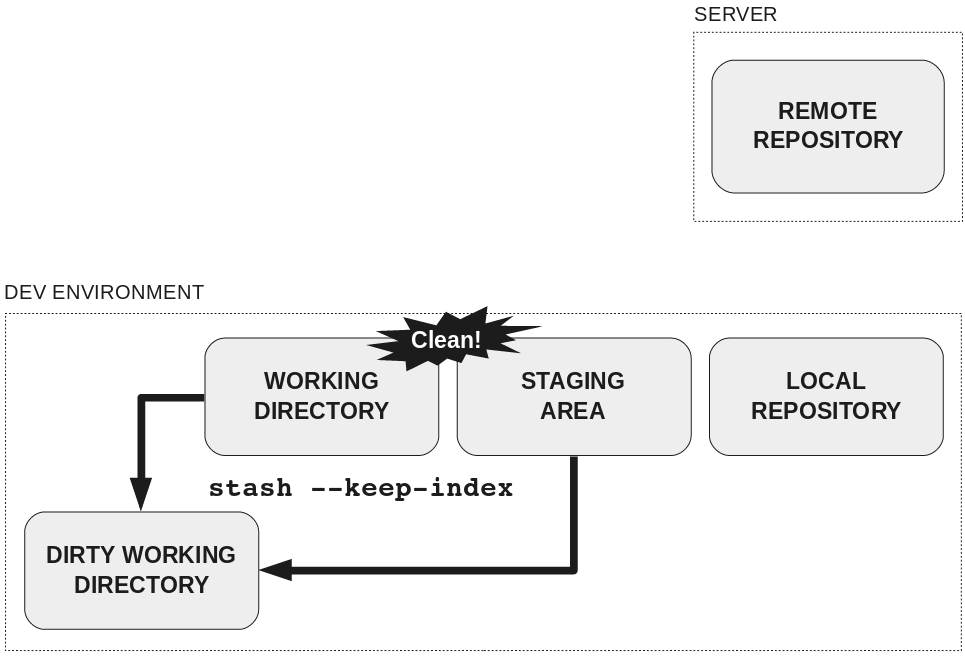

## Stash

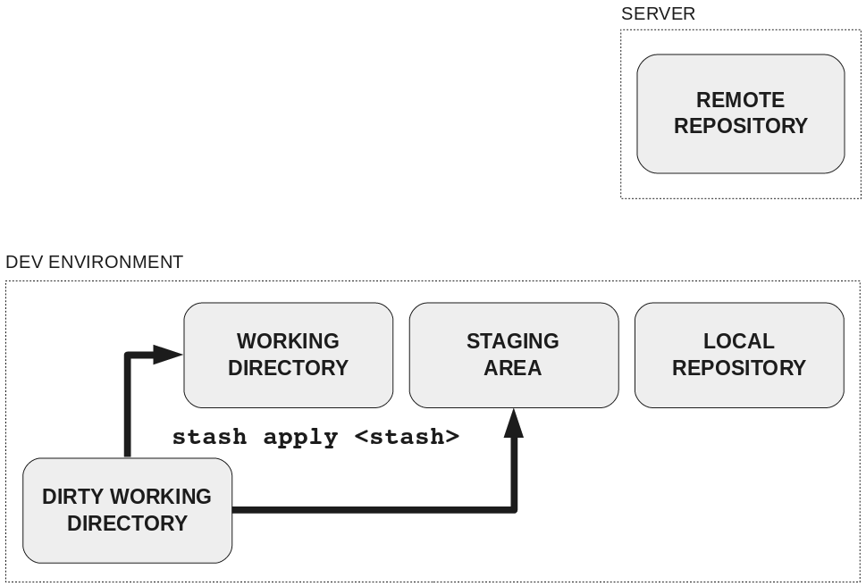

## Les branches

- `git branch branche`
- `git checkout branche`
- `git checkout -b branche`
- `git branch -D branche`
- `git push origin :branche`

https://learngitbranching.js.org/

## Historique de commits

- `git log`
- `git lg`

`git config --global alias.lg "log --`

`color --graph --pretty=format:`

`'%Cred%h%Creset -%C(yellow)%d%Creset`

`%s %Cgreen(%cr) %C(bold blue)<%an>%Creset'`

`--abbrev-commit --"` https://gist.github.com/johanmeiring/3002458

# GitHub

## Bonnes pratiques de collaboration sur GitHub

1. Créer une branche sur le dépôt (fork)
2. Ajouter des commits
3. Pusher la branche et les commits sur GitHub
4. Ouvrir une Pull Request (assigner des correcteurs)
5. Discuter, approuver et merge

## Autres bonnes pratiques en collaboration

- Les données utilisés pour faire une analyse peuvent être ajoutés au dépôt si le jeu de données est petit. Un grand jeu de données peut prendre de la place, et l’historique des changements dans le jeu de données, qui peut être problématique. Un dépôt peut être jusqu’à 1GB et un fichier peut être jusqu’à 100MB.
- .Rprofile, .Rdata, packrat

# Mises-en-situation

## Voir les différences

- Ajouter un fichier et l’envoyer au répertoire local
- Changer le contenu du fichier dans le répertoire de travail
- Afficher la liste des changements
- Ajouter le fichier à la mise-en-scene
- Changer le contenu du fichier
- Afficher la liste des changements dans l’environnement de travail
- Afficher la liste des changements dans la mise-en-scene

## Fusionner et avancer I

- Faites une branche A
- Créer une branche B
- Faire des changements sur la branche B
- Fusionner B dans A

## Fusionner et avancer II

- Faites une branche A
- Créer une branche B
- Faire des changements sur la branche B
- Faire des changements sur la branche A
- Fusionner B dans A

## Jouer avec les branches!

- Créer une branche A
- Créer une branche B
- Créer une branche C
- Supprimer la branche A locale
- Supprimer la branche B à distance
- Supprimer la branche C locale et à distance

## Mise-en-scène

- Créer une branche dans un répertoire local
- Créer des fichiers
- Envoyer au répertoire local
- Créer de nouveaux fichiers
- Changer des fichiers existants
- Distribuer les nouveaux fichiers et changements dans deux commits différents

## Fusionnement et conflits

- Créer une branche locale A
- Créer une branche locale B
- Créer un fichier sous le même nom, avec une différence dans les lignes
- Fusionner de B à A et résoudre le conflit
- Fusionner de A à B